# Visualization_2

Felix Tran

October 2, 2018

To get a more complete picture of your data, make lots of different graphs highlighting different aspects of your data.

Today we will talk about graphing features to produce graphs you would show to others.

```r
devtools::install_github('thomasp85/patchwork')
```

# Import data

```r
library(rnoaa)

weather_df =
  rnoaa::meteo_pull_monitors(c("USW00094728", "USC00519397", "USS0023B17S"),
                      var = c("PRCP", "TMIN", "TMAX"),
                      date_min = "2017-01-01",
                      date_max = "2017-12-31") %>%
  mutate(
    name = recode(id, USW00094728 = "CentralPark_NY",
                      USC00519397 = "Waikiki_HA",
                      USS0023B17S = "Waterhole_WA"),
    tmin = tmin / 10,
    tmax = tmax / 10) %>%
  select(name, id, everything())
weather_df
```

```
## # A tibble: 1,095 x 6
##    name           id          date        prcp  tmax  tmin
##    <chr>          <chr>       <date>     <dbl> <dbl> <dbl>
##  1 CentralPark_NY USW00094728 2017-01-01     0   8.9   4.4
##  2 CentralPark_NY USW00094728 2017-01-02    53   5     2.8
##  3 CentralPark_NY USW00094728 2017-01-03   147   6.1   3.9
##  4 CentralPark_NY USW00094728 2017-01-04     0  11.1   1.1
##  5 CentralPark_NY USW00094728 2017-01-05     0   1.1  -2.7
##  6 CentralPark_NY USW00094728 2017-01-06    13   0.6  -3.8
##  7 CentralPark_NY USW00094728 2017-01-07    81  -3.2  -6.6
##  8 CentralPark_NY USW00094728 2017-01-08     0  -3.8  -8.8
##  9 CentralPark_NY USW00094728 2017-01-09     0  -4.9  -9.9
## 10 CentralPark_NY USW00094728 2017-01-10     0   7.8  -6
## # ... with 1,085 more rows
```

# Scatterplot

Can add options to make graphs easier to read for others and yourself

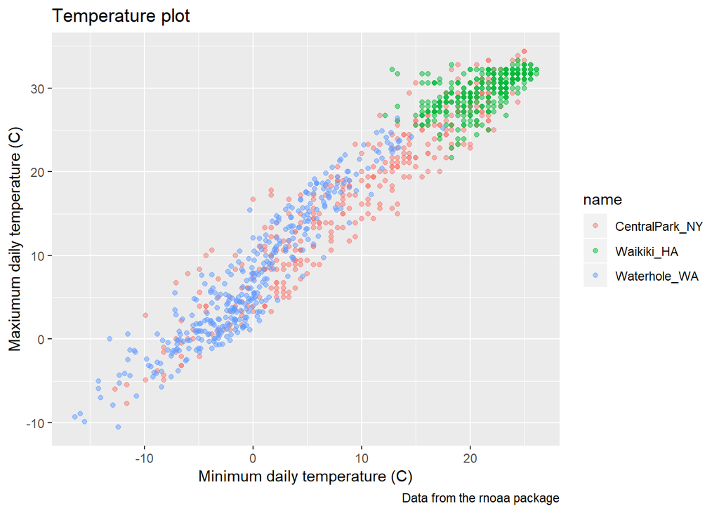

```r
ggplot(weather_df, aes(x = tmin, y = tmax)) +
  geom_point(aes(color = name), alpha = .5) +
  labs(
    title = "Temperature plot",
    x = "Minimum daily temperature (C)",
    y = "Maxiumum daily temperature (C)",
    caption = "Data from the rnoaa package"
  )
```

Tick marks and labels

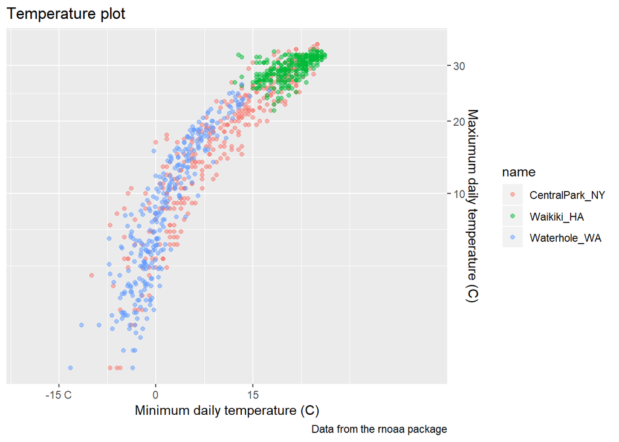

```r
ggplot(weather_df, aes(x = tmin, y = tmax)) +
  geom_point(aes(color = name), alpha = .5) +
  labs(
    title = "Temperature plot",
    x = "Minimum daily temperature (C)",
    y = "Maxiumum daily temperature (C)",
    caption = "Data from the rnoaa package"
  ) +
  scale_x_continuous(
    breaks = c(-15, 0, 15),
    labels = c("-15 C", "0", "15"),
    limits = c(-20, 42)
  ) +
  scale_y_continuous(
    position = "right",
    trans = "sqrt"
  )
```

# Colors and themes

Adjust colors

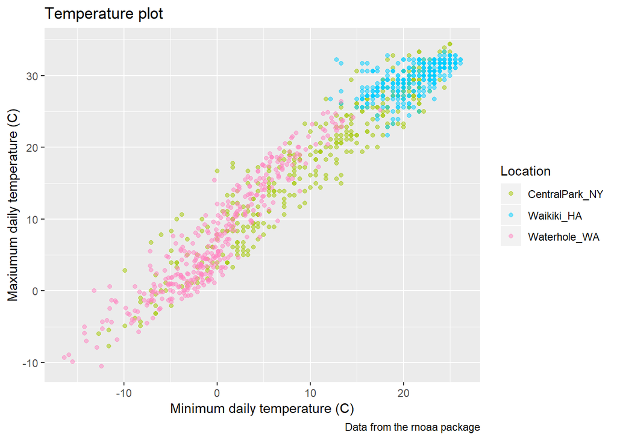

```r
ggplot(weather_df, aes(x = tmin, y = tmax)) +
  geom_point(aes(color = name), alpha = .5) +
  labs(
    title = "Temperature plot",
    x = "Minimum daily temperature (C)",
    y = "Maxiumum daily temperature (C)",
    caption = "Data from the rnoaa package"
  ) +
  scale_color_hue(h = c(100, 350),
                  l = 75,
                  name = "Location")
```

The viridis package installed with another package gives some color palettes for graphs

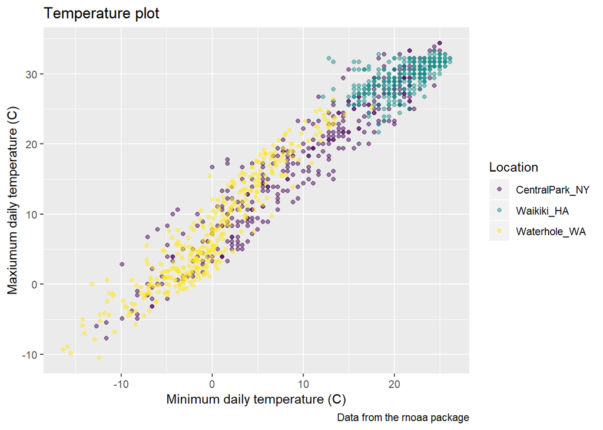

```r
ggplot(weather_df, aes(x = tmin, y = tmax)) +
  geom_point(aes(color = name), alpha = .5) +
  labs(
    title = "Temperature plot",
    x = "Minimum daily temperature (C)",
    y = "Maxiumum daily temperature (C)",
    caption = "Data from the rnoaa package"
  ) +
  viridis::scale_color_viridis(
    name = "Location",
    discrete = T
  )
```

Plot legend

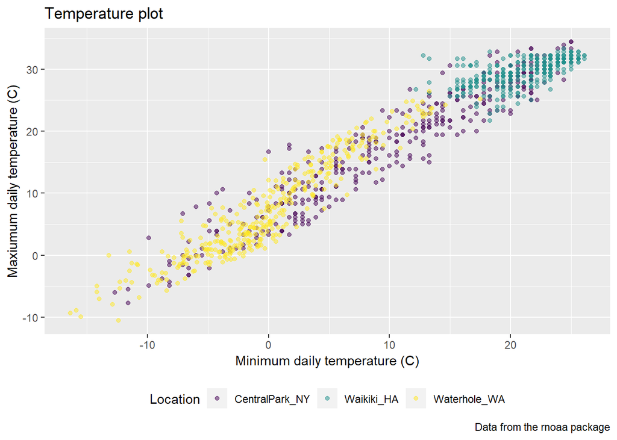

```r
ggplot(weather_df, aes(x = tmin, y = tmax)) +
  geom_point(aes(color = name), alpha = .5) +
  labs(
    title = "Temperature plot",
    x = "Minimum daily temperature (C)",
    y = "Maxiumum daily temperature (C)",
    caption = "Data from the rnoaa package"
  ) +
  viridis::scale_color_viridis(
    name = "Location",
    discrete = T
  ) +
  theme(legend.position = "bottom")
```

# Themes

Changing the theme

The order for theme_bw() and theme() matters! theme_bw() resets the overall theme of the plot so put theme() afterwards if you want to adjust things like legend position

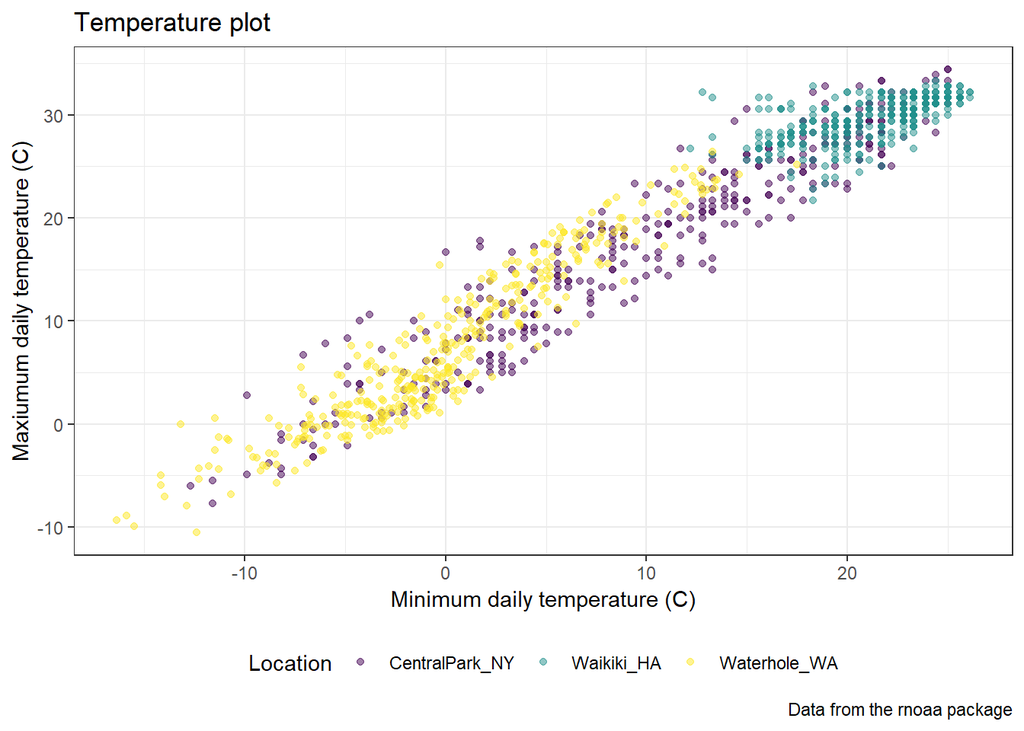

```r
ggplot(weather_df, aes(x = tmin, y = tmax)) +
  geom_point(aes(color = name), alpha = .5) +
  labs(
    title = "Temperature plot",
    x = "Minimum daily temperature (C)",
    y = "Maxiumum daily temperature (C)",
    caption = "Data from the rnoaa package"
  ) +
  viridis::scale_color_viridis(
    name = "Location",
    discrete = T
  ) +
  theme_bw() +
  theme(legend.position = "bottom")
```

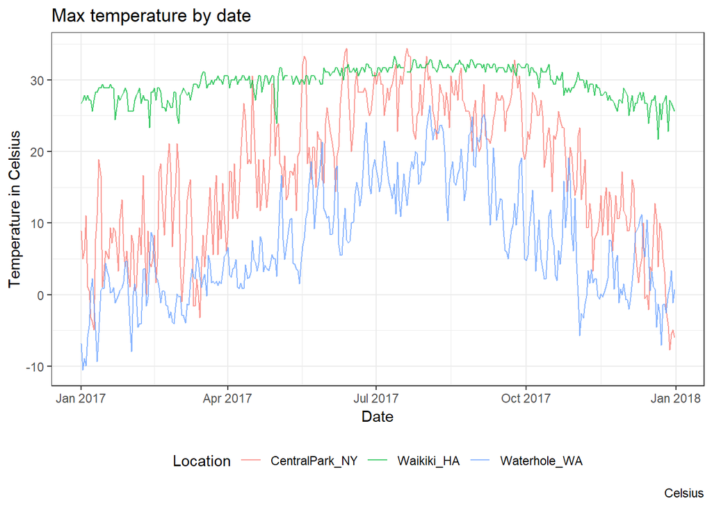

```r
ggplot(weather_df, aes(x = date, y = tmax)) +
  geom_line(aes(color = name), alpha = 0.75) +
  labs(
    title = "Max temperature by date",
    x = "Date",
    y = "Temperature in Celsius",
    caption = "Celsius"
  ) +
  scale_color_discrete(name = "Location") +
  theme_bw() +
  theme(legend.position = "bottom")
```

# Arguments to ’geom_*’ Demonstrate how the data paramter in geom_* can be used to stack a layer with

data distinct from the data used for the majority of the graph.

An application of this would be when you graph a large dataset, and then you want to graph on top of it summary information.

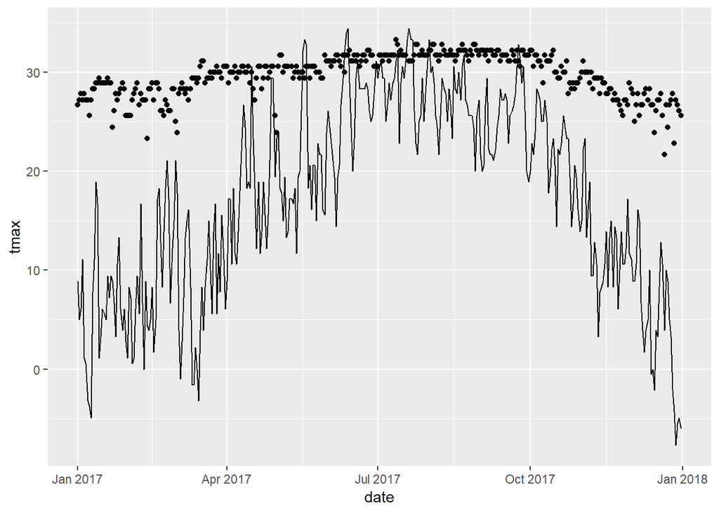

```r
centralpark_df <- weather_df %>%
  filter(name == "CentralPark_NY")
waikiki_df <- weather_df %>%
  filter(name == "Waikiki_HA")

ggplot(waikiki_df, aes(x = date, y = tmax)) +
  geom_point() +
  geom_line(data = centralpark_df)
```

# Patchwork

Patching together different plots into a single display.

Different from facet in that facet creates the same kind of plot many times contingent on a single variable in the dataset. Patchwork is for putting together fundamentally different graphs.

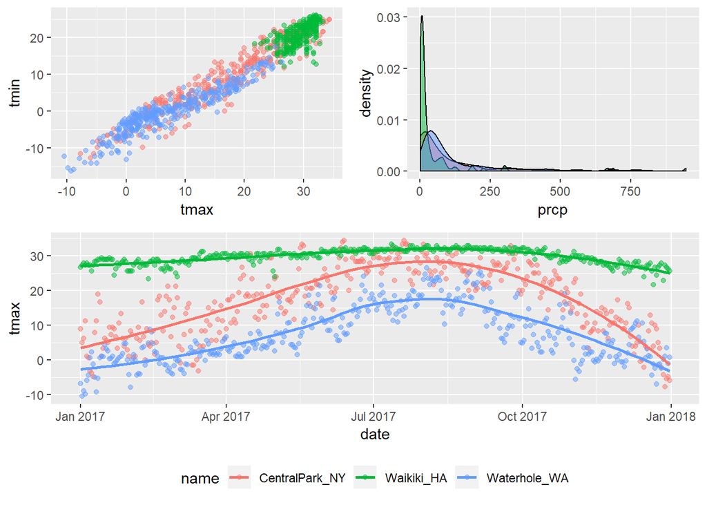

```r
library(patchwork)
tmax_tmin_p = ggplot(weather_df, aes(x = tmax, y = tmin, color = name)) +
  geom_point(alpha = .5) +
  theme(legend.position = "none")

prcp_dens_p = weather_df %>%
  filter(prcp > 0) %>%
  ggplot(aes(x = prcp, fill = name)) +
  geom_density(alpha = .5) +
  theme(legend.position = "none")

tmax_date_p = ggplot(weather_df, aes(x = date, y = tmax, color = name)) +
  geom_point(alpha = .5) +
  geom_smooth(se = FALSE) +
  theme(legend.position = "bottom")

(tmax_tmin_p + prcp_dens_p) / tmax_date_p
```

# Data manipulation

In the background, name is read as a factor in ggplot to determine order.

The forcats package allows us to change order of the values of the name variable when name is read as a factor variable.

fct_relevel lets you manually choose order of the variable you will order by

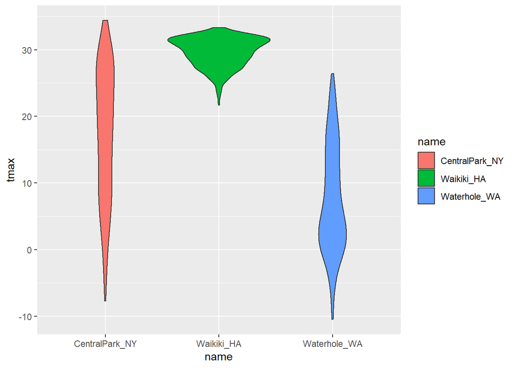

```r
ggplot(weather_df, aes(x = name, y = tmax, fill = name)) +
  geom_violin()
```

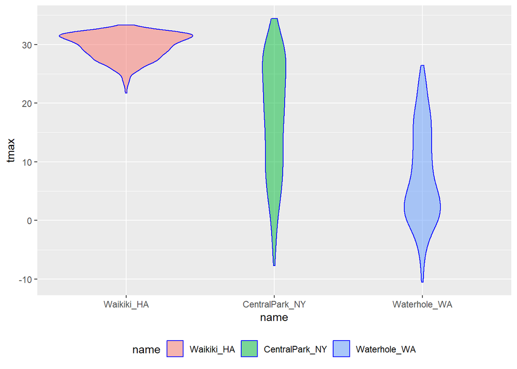

```r
weather_df %>%
  mutate(name = forcats::fct_relevel(name, c("Waikiki_HA", "CentralPark_NY", "Waterhole_WA"))) %>%
  ggplot(aes(x = name, y = tmax)) +
  geom_violin(aes(fill = name), color = "blue", alpha = .5) +
  theme(legend.position = "bottom")
```

fct_reorder lets you determine how to order the variable (e.g. by mean value of another variable)

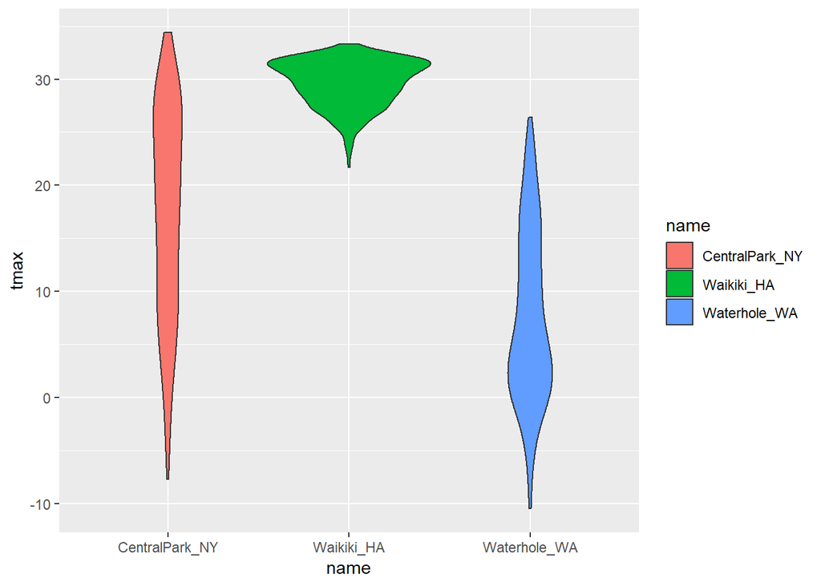

```r
ggplot(weather_df, aes(x = name, y = tmax, fill = name)) +
  geom_violin()
```

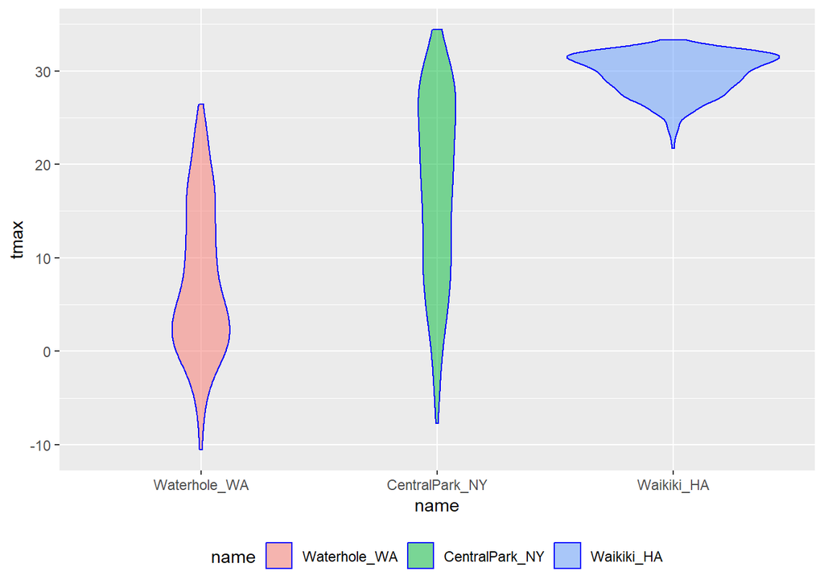

```r
weather_df %>%
  mutate(name = forcats::fct_reorder(name, tmax)) %>%
  ggplot(aes(x = name, y = tmax)) +
  geom_violin(aes(fill = name), color = "blue", alpha = .5) +
  theme(legend.position = "bottom")
```

Data manipulation is crucial for creating complex plots in ggplot. It often is easier to manipulate the data to fit your plotting needs than to add lots of options in ggplot to get it to plot your data as is.

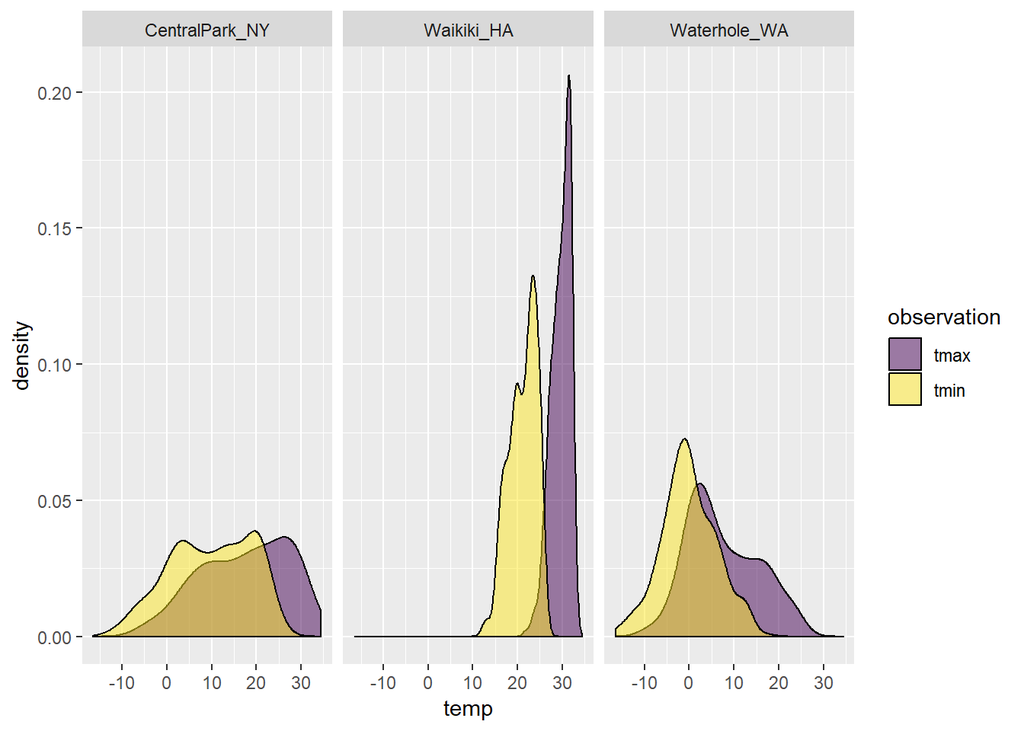

```r
weather_df %>%
  select(name, tmax, tmin) %>%
  gather(key = observation, value = temp, tmax:tmin) %>%
  ggplot(aes(x = temp, fill = observation)) +
  geom_density(alpha = .5) +
  facet_grid(~name) +
  viridis::scale_fill_viridis(discrete = TRUE)
```